# Intro to Generalized Linear Mixed Models

27 May 2026

## Goals for today

- Understand the structural components of generalized linear mixed models
- Understand the options for fitting GLMMs and their pros and cons
- Understand some of the diagnostics available for evaluating GLMM fits

## Forms of linear models

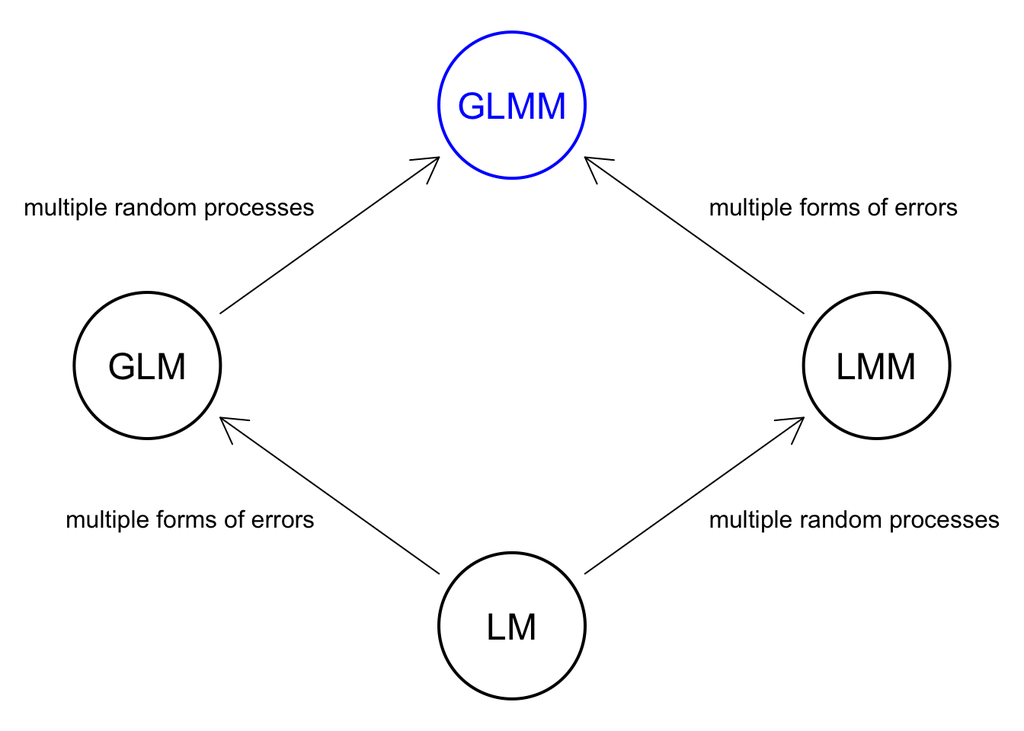

## Generalized linear mixed model

GLMMs combine the flexibility of non-normal distributions (GLMs) with the ability to address correlations among observations and nested data structures (LMMs)

## Generalized linear mixed model

Good news

- these extensions follow similar methods to GLMs and LMMs

Bad news

- these models are on the frontier of statistical research
- existing documentation is rather technical
- multiple approaches for fitting models; some with different results

## Generalized linear mixed model

Just like GLMs, GLMMs have three components:

1. Distribution of the data \(f(y; \theta)\)
2. Link function \(g(\eta)\)
3. Linear predictor \(\eta\)

## Generalized linear mixed model

Just like GLMs, we can assume a variety of data distributions

- Gaussian: continuous real values
- gamma: continuous positive values
- Bernoulli: binary outcomes
- binomial: discrete successes/trials
- Poisson: non-negative counts
- negative binomial: non-negative counts with extra variation
- zero-inflated Poisson & negative binomial

## Linear predictor for a GLM

We can write the linear predictor for GLMs as

\[ \eta = \beta_0 + \beta_1 x_1 + ... + \beta_k x_k \\ \Downarrow \\ \eta = \mathbf{X} \boldsymbol{\beta} \]

where the \(\beta_i\) are fixed effects of factors or covariates \(x_i\)

## Linear predictor for a GLMM

For GLMMs, our linear predictor also includes random effects

\[ \eta = \beta_0 + \beta_1 x_1 + \dots + \beta_k x_k + \alpha_0 + \alpha_1 z_1 + \dots + \alpha_l z_l\\ \Downarrow \\ \eta = \mathbf{X} \boldsymbol{\beta} + \mathbf{Z} \boldsymbol{\alpha} \]

where the \(\beta_i\) are fixed effects of factors or covariates \(x_i\)

and \(\alpha_i\) are random effects of factors or covariates \(z_i\)

## Generalized linear mixed model

### An example

Survival of fish \(i\) in some location \(j\) \((s_{i,j})\) as a function of its length at the time of tagging \((x_{i,j})\) and a random effect for location

\[ \begin{aligned} \text{data distribution:} & ~~~ y_{i,j} \sim \text{Bernoulli}(s_{i,j}) \\ \text{link function:} & ~~~ \text{logit}(s_{i,j}) = \text{log}\left(\frac{s_{i,j}}{1-s_{i,j}}\right) = \mu_{i,j} \\ \text{linear model:} & ~~~ \mu_{i,j} = (\beta_0 + \alpha_j) + \beta_1x_{i,j} \\ & ~~~ \alpha_j \sim \text{N}(0, \sigma_{\delta}^2) \end{aligned} \]

## Generalized linear mixed model

Note: fitting GLMMs is complex

Why? Because GLMMs involve solving an integral with no analytical solution

## Generalized linear mixed model

Note: fitting GLMMs is complex

Why? Because GLMMs involve solving an integral with no analytical solution

Recall that we think of *likelihoods* in terms of the *observed data*, but

the *random effects* in our model are *unobserved* random variables

## Generalized linear mixed model

Note: fitting GLMMs is complex

Why? Because GLMMs involve solving an integral with no analytical solution

Recall that we think of *likelihoods* in terms of the *observed data*, but

the *random effects* in our model are *unobserved* random variables

So we need to integrate them out of the likelihood

Best practices suggest we try to keep things simple - lots and lots of random effects become hard to handle

## Likelihood for GLMMs

The likelihood for a GLMM involves integrating over all possible random effects

\[ \mathcal{L}(y; \boldsymbol{\beta}, \phi, \boldsymbol{\nu}) = \prod_{i} \int \underbrace{f_d(y; \boldsymbol{\beta}, \phi, \boldsymbol{\alpha})}_{\text{distn for data}} ~ \underbrace{f_r(\boldsymbol{\alpha}; \boldsymbol{\nu})}_{\text{distn for RE}} d \boldsymbol{\alpha} \]

If \(f(y; \boldsymbol{\beta}, \phi, \boldsymbol{\alpha})\) is not Gaussian, we cannot remove it from the likelihood, which makes it *very* difficult to compute

## Approaches to fitting GLMMs

To avoid the integral, we will consider 3 methods that approximate the likelihood

They all have pros and cons so it’s not possible to pick the “best”

## Penalized quasi-likelihood

Produces linearized version of the response & then uses LMM methods to fit it

Pros

- fast, flexible, and widely implemented

Cons

- not a true likelihood, making inference challenging
- only asymptotically correct
- biased for binomial and Poisson with small samples

## Laplace approximation

Uses Laplace approximation for computing integrals of the form \(\int e^{h(x)} d x\), which is a good approximation of the integral in a GLMM likelihood

Pros

- approximation of true likelihood rather than quasi-likelihood
- more accurate than PQL

Cons

- slower and less flexible than PQL
- may be impossible to compute for complex models

## Gauss-Hermite quadrature

An expansion of Laplace approximation where the integrand is evaluated at more than one point

Pros

- More accurate than Laplace

Cons

- Slow and computationally intense
- Limited to a few random effects (one in practice)

## Markov Chain Monte Carlo

Sampling from an estimated posterior distribution rather than computing the integral

- This is what is done in Bayesian estimation
- MCMC has the ability to handle much more complex random effects

## Fitting GLMMs

### Example

Let’s consider a long-term study of invasive brown tree snakes in Guam

- Introduced to the island shortly after WWII
- Voracious predators on native birds and other vertebrates

## Brown tree snakes

Our data consist of counts of the number of eggs per female at 10 locations over 13 years

We are interested in the fixed effect of body size and the random effects of location and year

We’ll begin with only the effects of body size and location

## Brown tree snakes

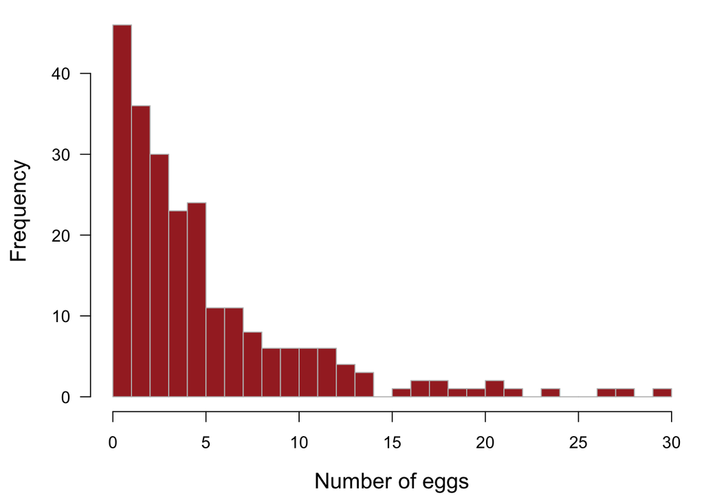

## Size versus fecundity by location

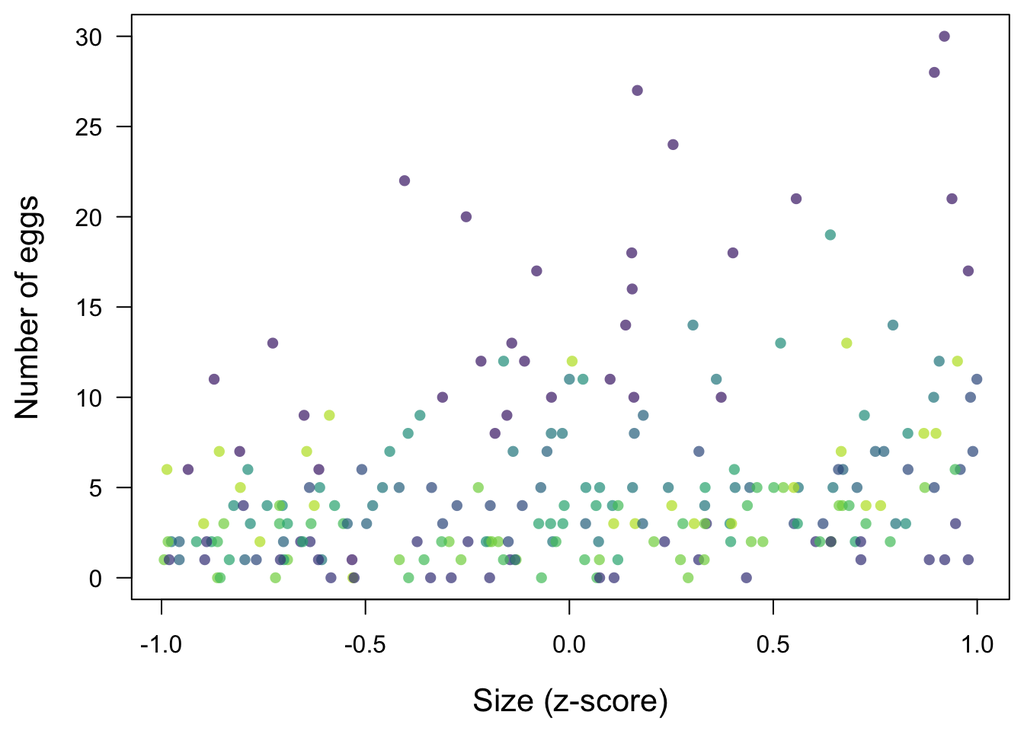

## Size versus fecundity by year

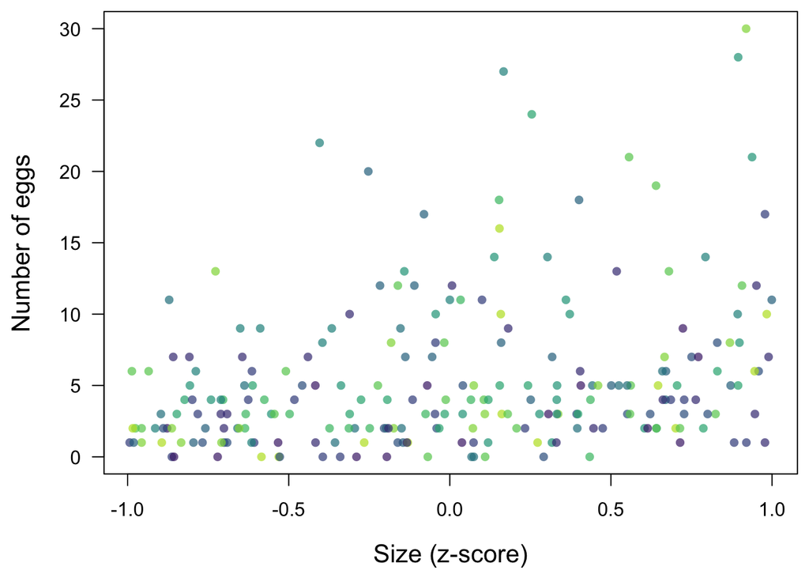

## Let’s fit some models

### Using penalized quasi-likelihood

```r
## fit model via penalized quasi-likelihood
fit_pql <- MASS::glmmPQL(eggs ~ size, random = ~ 1|loc,
                         family = poisson,
                         data = df_eggs)
```

## Let’s fit some models

### Using Laplace approximation

```r
## load {lme4}
library(lme4)

## set control parameters for model fitting
cntrl <- glmerControl(optimizer = "bobyqa", tol = 1e-4, optCtrl = list(maxfun = 100000))

## fit model via Laplace approximation
fit_lap <- glmer(eggs ~ size + (1|loc),
                 family = poisson,
                 data = df_eggs,
                 control = cntrl)
```

## Let’s fit some models

### Using Gauss-Hermite quadrature

```r
## fit model via Gauss-Hermite quadrature
fit_ghq <- glmer(eggs ~ size + (1|loc),
                 family = poisson,
                 data = df_eggs,
                 nAGQ = 40,
                 control = cntrl)
```

## Brown treesnakes

Summary of the results from the 3 methods

```
##             PQL    SE Laplace    SE   GHQ    SE
## intercept 1.396 0.209   1.387 0.209 1.387 0.209
## body size 0.500 0.059   0.500 0.051 0.500 0.052
## sigma_loc 0.804    NA   0.652    NA 0.652    NA
```

```r
## true values
intercept = 1
body size = 0.5
sigma_loc = 0.5
```

## Brown tree snakes

What if we also want to include the random effect of year?

- `glmmPQL` only allows for nested random effects
- `glmer(..., nAGQ = pts)` only allows for one random effect
- we can use Laplace approximation via `glmer`

## Fit model via Laplace approximation

```r
## fit GLMM with location & year
fit_2_lap <- glmer(eggs ~ size + (1|loc) + (1|year),
                   family = poisson,
                   data = df_eggs)
```

## Brown tree snakes

### Laplace only

```
##            Laplace    SE
## intercept    1.359 0.216
## body size    0.551 0.053
## sigma_loc    0.635    NA
## sigma_year   0.253    NA
```

```r
## true values
intercept = 1
body size = 0.5
sigma_loc = 0.5
sigma_year = 0.25
```

## Summary of GLMM methods

- Simpler models will work better
- Gauss-Hermite quadrature likely to work best with only one random effect
- Laplace approximation likely to work best with multiple random effects
- With complex models, some things may not be possible in ML framework

## Summary of GLMM methods

| Method | Advantages | Disadvantages | R functions |
| --- | --- | --- | --- |
| Penalized quasi-likelihood | Flexible, widely implemented | inference may be inappropriate; potentially biased | `MASS::glmmPQL` |
| Laplace approximation | More accurate than PQL | Slower and less flexible than PQL | `glmer` `glmmsr::glmm` `glmmML::glmmML` |
| Gauss-Hermite quadrature | More accurate than Laplace | Slower than Laplace; limited random effects | `glmer` `glmmsr::glmm` `glmmML::glmmML` |

Adapted from Bolker et al (2009)

## Additional Resources

https://bbolker.github.io/mixedmodels-misc/glmmFAQ.html